# Depuración y análisis exploratorio

[Edimer David Jaramillo (Sidereus)](https://edimer.github.io/)

30/3/2021

[figure not shown]

# Competencia

- [Link de competencia](https://www.datasource.ai/es/home/data-science-competitions-for-startups/prediccion-de-la-intencion-de-compra-en-una-pagina-web)

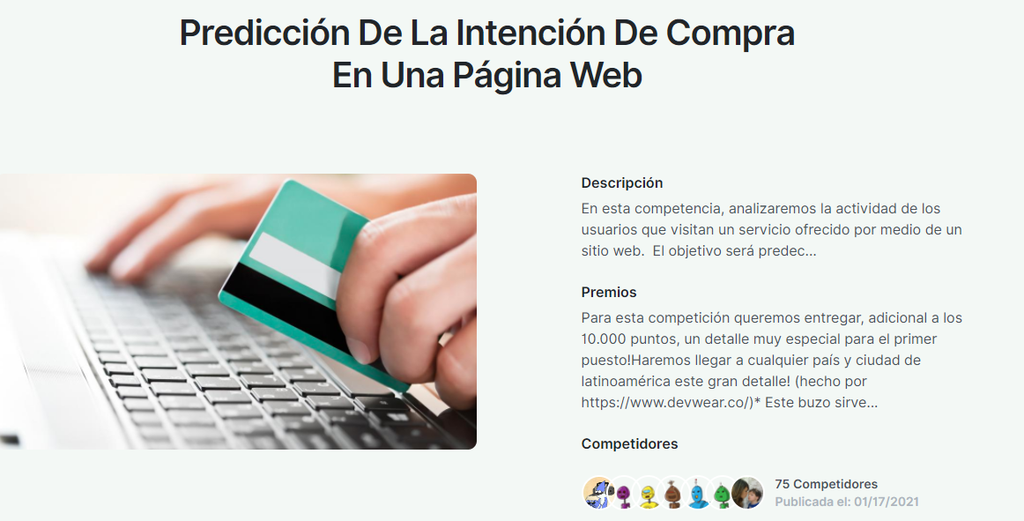

# Variables

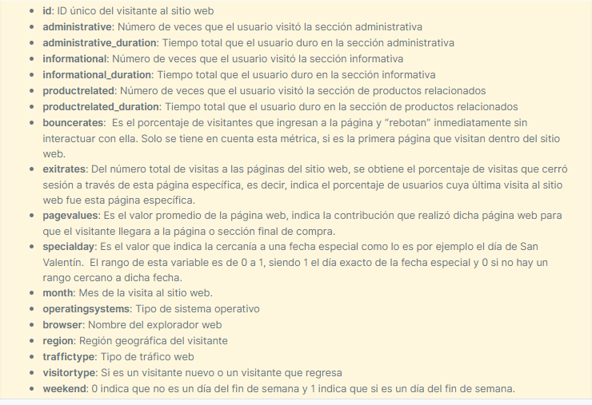

# Datos Train

```r
library(tidyverse)
library(janitor)
library(lubridate)

data_train <- read_csv("data/train.csv") %>%
  clean_names() %>%
  mutate(month = as.factor(month),
         operating_systems = as.factor(operating_systems),
         browser = as.factor(browser),
         region = as.factor(region),
         traffic_type = as.factor(traffic_type),
         visitor_type = as.factor(visitor_type),
         weekend = as.factor(weekend),
         month = fct_relevel(month, "Feb", "Mar", "May", "June", "Jul",
                             "Aug", "Sep", "Oct", "Nov", "Dec"))
data_train %>% head()
```

| id | administrative | administrative_duration | informational | informational_duration | product_related | product_related_duration | bounce_rates | exit_rates | page_values | special_day | month | operating_systems | browser | region | traffic_type | visitor_type | weekend | revenue |
| --- | --- | --- | --- | --- | --- | --- | --- | --- | --- | --- | --- | --- | --- | --- | --- | --- | --- | --- |
| 1 | 0 | 0 | 0 | 0 | 5 | 81.08333 | 0.04 | 0.05000000 | 0.00000 | 0 | Dec | 3 | 2 | 1 | 2 | New_Visitor | FALSE | 0 |
| 2 | 0 | 0 | 0 | 0 | 3 | 189.00000 | 0.00 | 0.06666667 | 0.00000 | 0 | Mar | 3 | 2 | 8 | 1 | Returning_Visitor | FALSE | 0 |
| 3 | 0 | 0 | 1 | 132 | 8 | 445.00000 | 0.00 | 0.01428571 | 0.00000 | 0 | Mar | 3 | 2 | 4 | 14 | Returning_Visitor | TRUE | 0 |
| 4 | 0 | 0 | 0 | 0 | 3 | 0.00000 | 0.20 | 0.20000000 | 0.00000 | 0 | Mar | 1 | 8 | 2 | 1 | Returning_Visitor | FALSE | 0 |
| 5 | 0 | 0 | 0 | 0 | 4 | 14.00000 | 0.10 | 0.15000000 | 0.00000 | 0 | Mar | 3 | 2 | 1 | 1 | Returning_Visitor | FALSE | 0 |
| 6 | 0 | 0 | 0 | 0 | 15 | 89.38333 | 0.00 | 0.01250000 | 39.64975 | 0 | Oct | 2 | 2 | 6 | 2 | New_Visitor | TRUE | 1 |

## Niveles de factores

```r
data_train %>%
  select(is.factor) %>%
  map(~levels(.x))
```

```
## $month
##  [1] "Feb"  "Mar"  "May"  "June" "Jul"  "Aug"  "Sep"  "Oct"  "Nov"  "Dec"
##
## $operating_systems
## [1] "1" "2" "3" "4" "5" "6" "7" "8"
##
## $browser
##  [1] "1"  "2"  "3"  "4"  "5"  "6"  "7"  "8"  "9"  "10" "11" "12" "13"
##
## $region
## [1] "1" "2" "3" "4" "5" "6" "7" "8" "9"
##
## $traffic_type
##  [1] "1"  "2"  "3"  "4"  "5"  "6"  "7"  "8"  "9"  "10" "11" "12" "13" "14" "15"
## [16] "16" "17" "18" "19" "20"
##
## $visitor_type
## [1] "New_Visitor"       "Other"             "Returning_Visitor"
##
## $weekend
## [1] "FALSE" "TRUE"
```

# Datos Test

```r
data_test <- read_csv("data/test.csv") %>%
  clean_names() %>%
  mutate(month = as.factor(month),
         operating_systems = as.factor(operating_systems),
         browser = as.factor(browser),
         region = as.factor(region),
         traffic_type = as.factor(traffic_type),
         visitor_type = as.factor(visitor_type),
         weekend = as.factor(weekend),
         month = fct_relevel(month, "Feb", "Mar", "May", "June", "Jul",
                             "Aug", "Sep", "Oct", "Nov", "Dec"))
data_test %>% head()
```

| id | administrative | administrative_duration | informational | informational_duration | product_related | product_related_duration | bounce_rates | exit_rates | page_values | special_day | month | operating_systems | browser | region | traffic_type | visitor_type | weekend |
| --- | --- | --- | --- | --- | --- | --- | --- | --- | --- | --- | --- | --- | --- | --- | --- | --- | --- |
| 1 | 3 | 142.5000 | 0 | 0.00 | 48 | 1052.2560 | 0.004347826 | 0.013043478 | 0.000000 | 0 | Nov | 1 | 8 | 6 | 11 | Returning_Visitor | FALSE |
| 2 | 6 | 437.3913 | 2 | 235.55 | 83 | 2503.8818 | 0.002197802 | 0.004916136 | 2.086218 | 0 | Mar | 2 | 2 | 3 | 2 | Returning_Visitor | FALSE |
| 3 | 1 | 41.1250 | 0 | 0.00 | 126 | 4310.0047 | 0.000687831 | 0.012822843 | 3.451072 | 0 | Nov | 2 | 2 | 2 | 2 | Returning_Visitor | FALSE |
| 4 | 2 | 141.0000 | 0 | 0.00 | 10 | 606.6667 | 0.008333333 | 0.026388889 | 36.672294 | 0 | Aug | 2 | 5 | 7 | 4 | Returning_Visitor | FALSE |
| 5 | 18 | 608.1400 | 6 | 733.80 | 168 | 4948.3988 | 0.006631763 | 0.013527508 | 10.150644 | 0 | Aug | 2 | 2 | 3 | 1 | Returning_Visitor | TRUE |
| 6 | 1 | 22.0000 | 0 | 0.00 | 9 | 415.2500 | 0.033333333 | 0.048148148 | 0.000000 | 0 | Mar | 3 | 3 | 1 | 1 | Returning_Visitor | FALSE |

## Niveles de factores

```r
data_test %>%
  select(is.factor) %>%
  map(~levels(.x))
```

```
## $month
##  [1] "Feb"  "Mar"  "May"  "June" "Jul"  "Aug"  "Sep"  "Oct"  "Nov"  "Dec"
##
## $operating_systems
## [1] "1" "2" "3" "4" "5" "6" "7" "8"
##
## $browser
##  [1] "1"  "2"  "3"  "4"  "5"  "6"  "7"  "8"  "10" "11" "12" "13"
##
## $region
## [1] "1" "2" "3" "4" "5" "6" "7" "8" "9"
##
## $traffic_type
##  [1] "1"  "2"  "3"  "4"  "5"  "6"  "7"  "8"  "9"  "10" "11" "13" "14" "15" "18"
## [16] "19" "20"
##
## $visitor_type
## [1] "New_Visitor"       "Other"             "Returning_Visitor"
##
## $weekend
## [1] "FALSE" "TRUE"
```

# Descriptivo

## Descriptivo train

```r
library(skimr)
skim(data_train)
```

Data summary

| Name | data_train |
| --- | --- |
| Number of rows | 8631 |
| Number of columns | 19 |
| _______________________ |  |
| Column type frequency: |  |
| factor | 7 |
| numeric | 12 |
| ________________________ |  |
| Group variables | None |

**Variable type: factor**

| skim_variable | n_missing | complete_rate | ordered | n_unique | top_counts |
| --- | --- | --- | --- | --- | --- |
| month | 0 | 1 | FALSE | 10 | May: 2308, Nov: 2116, Mar: 1355, Dec: 1216 |
| operating_systems | 0 | 1 | FALSE | 8 | 2: 4659, 1: 1810, 3: 1760, 4: 331 |
| browser | 0 | 1 | FALSE | 13 | 2: 5556, 1: 1732, 4: 523, 5: 336 |
| region | 0 | 1 | FALSE | 9 | 1: 3340, 3: 1688, 2: 812, 4: 811 |
| traffic_type | 0 | 1 | FALSE | 20 | 2: 2746, 1: 1698, 3: 1475, 4: 712 |
| visitor_type | 0 | 1 | FALSE | 3 | Ret: 7389, New: 1181, Oth: 61 |
| weekend | 0 | 1 | FALSE | 2 | FAL: 6652, TRU: 1979 |

**Variable type: numeric**

| skim_variable | n_missing | complete_rate | mean | sd | p0 | p25 | p50 | p75 | p100 | hist |
| --- | --- | --- | --- | --- | --- | --- | --- | --- | --- | --- |
| id | 0 | 1 | 4316.00 | 2491.70 | 1 | 2158.50 | 4316.00 | 6473.50 | 8631.00 | ▇▇▇▇▇ |
| administrative | 0 | 1 | 2.30 | 3.29 | 0 | 0.00 | 1.00 | 4.00 | 27.00 | ▇▁▁▁▁ |
| administrative_duration | 0 | 1 | 80.51 | 173.09 | 0 | 0.00 | 7.62 | 91.95 | 2720.50 | ▇▁▁▁▁ |
| informational | 0 | 1 | 0.51 | 1.28 | 0 | 0.00 | 0.00 | 0.00 | 24.00 | ▇▁▁▁▁ |
| informational_duration | 0 | 1 | 34.31 | 135.65 | 0 | 0.00 | 0.00 | 0.00 | 2195.30 | ▇▁▁▁▁ |
| product_related | 0 | 1 | 31.70 | 44.38 | 0 | 7.00 | 18.00 | 37.00 | 705.00 | ▇▁▁▁▁ |
| product_related_duration | 0 | 1 | 1195.71 | 1828.49 | 0 | 186.48 | 602.88 | 1477.56 | 43171.23 | ▇▁▁▁▁ |
| bounce_rates | 0 | 1 | 0.02 | 0.05 | 0 | 0.00 | 0.00 | 0.02 | 0.20 | ▇▁▁▁▁ |
| exit_rates | 0 | 1 | 0.04 | 0.05 | 0 | 0.01 | 0.03 | 0.05 | 0.20 | ▇▂▁▁▁ |
| page_values | 0 | 1 | 5.93 | 18.84 | 0 | 0.00 | 0.00 | 0.00 | 361.76 | ▇▁▁▁▁ |
| special_day | 0 | 1 | 0.06 | 0.20 | 0 | 0.00 | 0.00 | 0.00 | 1.00 | ▇▁▁▁▁ |
| revenue | 0 | 1 | 0.15 | 0.36 | 0 | 0.00 | 0.00 | 0.00 | 1.00 | ▇▁▁▁▂ |

## Descriptivo test

```r
skim(data_test)
```

Data summary

| Name | data_test |
| --- | --- |
| Number of rows | 3699 |
| Number of columns | 18 |
| _______________________ |  |
| Column type frequency: |  |
| factor | 7 |
| numeric | 11 |
| ________________________ |  |
| Group variables | None |

**Variable type: factor**

| skim_variable | n_missing | complete_rate | ordered | n_unique | top_counts |
| --- | --- | --- | --- | --- | --- |
| month | 0 | 1 | FALSE | 10 | May: 1056, Nov: 882, Mar: 552, Dec: 511 |
| operating_systems | 0 | 1 | FALSE | 8 | 2: 1942, 3: 795, 1: 775, 4: 147 |
| browser | 0 | 1 | FALSE | 12 | 2: 2405, 1: 730, 4: 213, 5: 131 |
| region | 0 | 1 | FALSE | 9 | 1: 1440, 3: 715, 4: 371, 2: 324 |
| traffic_type | 0 | 1 | FALSE | 17 | 2: 1167, 1: 753, 3: 577, 4: 357 |
| visitor_type | 0 | 1 | FALSE | 3 | Ret: 3162, New: 513, Oth: 24 |
| weekend | 0 | 1 | FALSE | 2 | FAL: 2810, TRU: 889 |

**Variable type: numeric**

| skim_variable | n_missing | complete_rate | mean | sd | p0 | p25 | p50 | p75 | p100 | hist |
| --- | --- | --- | --- | --- | --- | --- | --- | --- | --- | --- |
| id | 0 | 1 | 1850.00 | 1067.95 | 1 | 925.50 | 1850.00 | 2774.50 | 3699.00 | ▇▇▇▇▇ |
| administrative | 0 | 1 | 2.34 | 3.39 | 0 | 0.00 | 1.00 | 4.00 | 24.00 | ▇▂▁▁▁ |
| administrative_duration | 0 | 1 | 81.54 | 185.12 | 0 | 0.00 | 7.00 | 95.62 | 3398.75 | ▇▁▁▁▁ |
| informational | 0 | 1 | 0.49 | 1.24 | 0 | 0.00 | 0.00 | 0.00 | 14.00 | ▇▁▁▁▁ |
| informational_duration | 0 | 1 | 34.84 | 152.00 | 0 | 0.00 | 0.00 | 0.00 | 2549.38 | ▇▁▁▁▁ |
| product_related | 0 | 1 | 31.81 | 44.71 | 0 | 7.00 | 18.00 | 39.00 | 517.00 | ▇▁▁▁▁ |
| product_related_duration | 0 | 1 | 1192.51 | 2099.29 | 0 | 181.28 | 588.50 | 1424.82 | 63973.52 | ▇▁▁▁▁ |
| bounce_rates | 0 | 1 | 0.02 | 0.05 | 0 | 0.00 | 0.00 | 0.02 | 0.20 | ▇▁▁▁▁ |
| exit_rates | 0 | 1 | 0.04 | 0.05 | 0 | 0.01 | 0.03 | 0.05 | 0.20 | ▇▂▁▁▁ |
| page_values | 0 | 1 | 5.79 | 17.92 | 0 | 0.00 | 0.00 | 0.00 | 270.78 | ▇▁▁▁▁ |
| special_day | 0 | 1 | 0.07 | 0.21 | 0 | 0.00 | 0.00 | 0.00 | 1.00 | ▇▁▁▁▁ |

# Exploratorio train

```r
library(tidyquant)
library(ggsci)
theme_set(theme_tq())
colores <- scale_color_manual(values = c("#EE0000FF", "#008EA0FF"))
relleno <- scale_fill_manual(values = c("#EE0000FF", "#008EA0FF"))
```

## Distribuciones numéricas

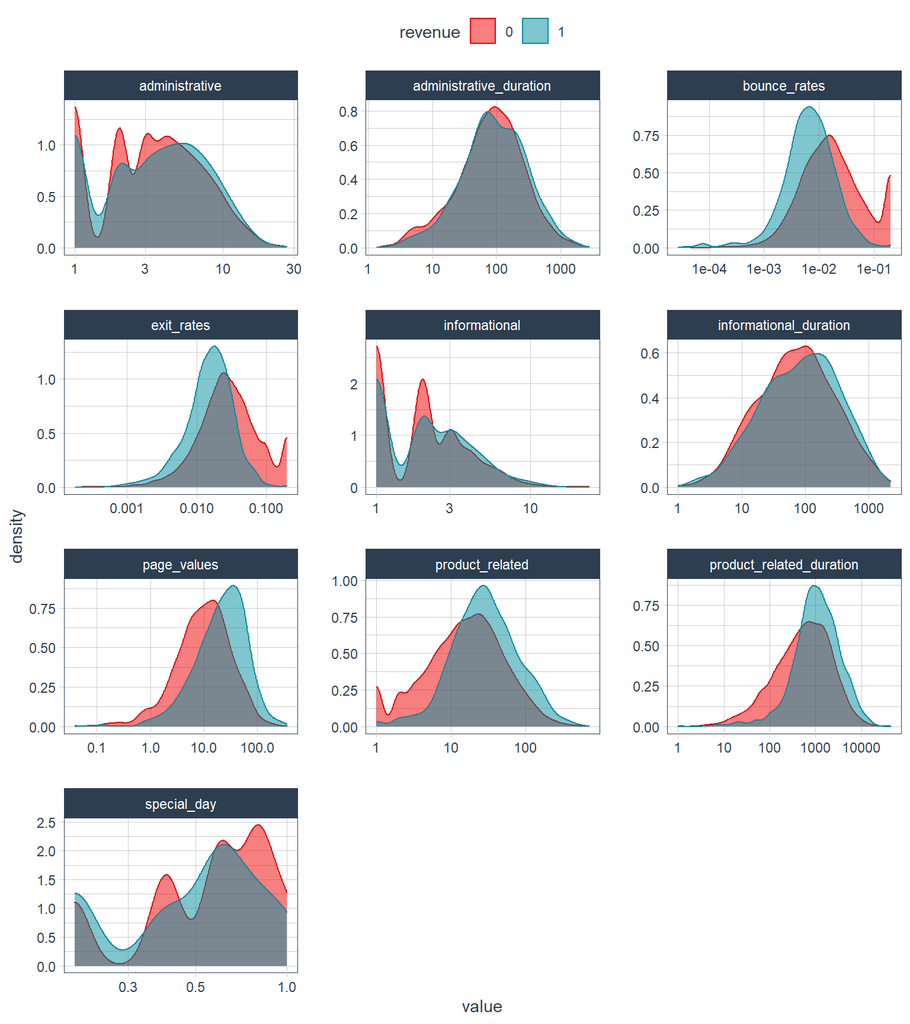

```r
data_train %>%
  select(!is.factor, -id) %>%
  mutate(revenue = as.factor(revenue)) %>%
  pivot_longer(cols = -revenue) %>%
  ggplot(aes(x = value, fill = revenue, color = revenue)) +
  facet_wrap(~name, scales = "free", ncol = 3) +
  geom_density(alpha = 0.5) +
  scale_x_log10() +
  colores +
  relleno +
  theme(legend.position = "top")
```

## Distribución categóricas

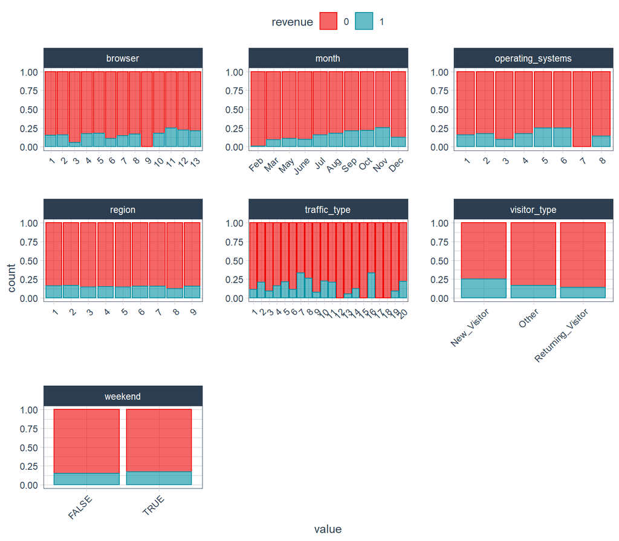

```r
data_train %>%
  select(is.factor, revenue) %>%
  mutate(revenue = as.factor(revenue)) %>%
  pivot_longer(cols = -revenue) %>%
  ggplot(aes(x = value, fill = revenue, color = revenue)) +
  facet_wrap(~name, scales = "free") +
  geom_bar(position = "fill", alpha = 0.6) +
  colores +
  relleno +
  theme(axis.text.x = element_text(angle = 45, hjust = 1),
        legend.position = "top")
```

# Feature Engineering

- Obtengo las siguientes nuevas variables:
  - **`semestre`:** Se observan ligeras diferencias entre los meses iniciales (primer semestre) y finales (segundo semestre) del año.
  - **`trimestre`:** trimestres.
  - **`mes_finsem`:** interacción de mes y fin de semana. Uno las dos variables separadas por guión al piso (_.)
  - **`tiempos_total`:** sumo todos los tiempos para cada cliente. Se suman `administrative_duration`, `informational_duration` y `productrelated_duration`.
  - **`visitas_total`:** sumo todas las variables relacionadas con visitas en las secciones de la página web. Se suman `administrative`, `informational` y `productrelated`
  - **`tiempo_promedio`:** divido la nueva variable `tiempos_total` en `visitas_total` para conocer el tiempo promedio que el usuario dura en cada visita a la página web.
  - **`rate_pagevalues_tiempo`:** divido la variable `page_values` en `tiempos_total`. Supongo que si la contribución de la página web para que el usuario llegara a esa sección de la compra es mayor, también tendra una sumatoria de tiempo mayor, cuyo cociente deberá ser cercano a 1, sin embargo, si la contribución es alta y el tiempo es bajo, el cociente será superior a 1 y sino será inferior a 1.
  - **`inter_pagevalues_tiempo`:** multiplico la variable `page_values` por `tiempos_total`.

## Train

```r
train_final <- data_train %>%
  mutate(
    semestre = if_else(
      month %in% c("Feb", "Mar", "May", "June"),
      true = "Semestre1",
      false = "Semestre2"
    ),
    trimestre = if_else(
      month %in% c("Feb", "Mar"),
      true = "Trimestre1",
      false = if_else(
        month %in% c("May", "June"),
        true = "Trimestre2",
        false = if_else(
          month %in% c("Jul", "Aug", "Sep"),
          true = "Trimestre3",
          false = "Trimestre4"
        )
      )
    ),
    mes_finsem = paste0(month, "_" , weekend),
    tiempos_total = administrative_duration + informational_duration
    + product_related_duration,
    visitas_total = administrative + informational + product_related,
    tiempo_promedio = if_else(
      tiempos_total > 0,
      true = tiempos_total / visitas_total,
      false = 0
    ),
    rate_pagevalues_tiempo = if_else(
      page_values > 0,
      true = page_values / tiempos_total,
      false = 0
    ),
    inter_pagevalues_tiempo = page_values * tiempos_total
  )

train_final %>% head()
```

| id | administrative | administrative_duration | informational | informational_duration | product_related | product_related_duration | bounce_rates | exit_rates | page_values | special_day | month | operating_systems | browser | region | traffic_type | visitor_type | weekend | revenue | semestre | trimestre | mes_finsem | tiempos_total | visitas_total | tiempo_promedio | rate_pagevalues_tiempo | inter_pagevalues_tiempo |
| --- | --- | --- | --- | --- | --- | --- | --- | --- | --- | --- | --- | --- | --- | --- | --- | --- | --- | --- | --- | --- | --- | --- | --- | --- | --- | --- |
| 1 | 0 | 0 | 0 | 0 | 5 | 81.08333 | 0.04 | 0.05000000 | 0.00000 | 0 | Dec | 3 | 2 | 1 | 2 | New_Visitor | FALSE | 0 | Semestre2 | Trimestre4 | Dec_FALSE | 81.08333 | 5 | 16.216667 | 0.0000000 | 0.000 |
| 2 | 0 | 0 | 0 | 0 | 3 | 189.00000 | 0.00 | 0.06666667 | 0.00000 | 0 | Mar | 3 | 2 | 8 | 1 | Returning_Visitor | FALSE | 0 | Semestre1 | Trimestre1 | Mar_FALSE | 189.00000 | 3 | 63.000000 | 0.0000000 | 0.000 |
| 3 | 0 | 0 | 1 | 132 | 8 | 445.00000 | 0.00 | 0.01428571 | 0.00000 | 0 | Mar | 3 | 2 | 4 | 14 | Returning_Visitor | TRUE | 0 | Semestre1 | Trimestre1 | Mar_TRUE | 577.00000 | 9 | 64.111111 | 0.0000000 | 0.000 |
| 4 | 0 | 0 | 0 | 0 | 3 | 0.00000 | 0.20 | 0.20000000 | 0.00000 | 0 | Mar | 1 | 8 | 2 | 1 | Returning_Visitor | FALSE | 0 | Semestre1 | Trimestre1 | Mar_FALSE | 0.00000 | 3 | 0.000000 | 0.0000000 | 0.000 |
| 5 | 0 | 0 | 0 | 0 | 4 | 14.00000 | 0.10 | 0.15000000 | 0.00000 | 0 | Mar | 3 | 2 | 1 | 1 | Returning_Visitor | FALSE | 0 | Semestre1 | Trimestre1 | Mar_FALSE | 14.00000 | 4 | 3.500000 | 0.0000000 | 0.000 |
| 6 | 0 | 0 | 0 | 0 | 15 | 89.38333 | 0.00 | 0.01250000 | 39.64975 | 0 | Oct | 2 | 2 | 6 | 2 | New_Visitor | TRUE | 1 | Semestre2 | Trimestre4 | Oct_TRUE | 89.38333 | 15 | 5.958889 | 0.4435922 | 3544.027 |

## Test

```r
test_final <- data_test %>%
  mutate(
    semestre = if_else(
      month %in% c("Feb", "Mar", "May", "June"),
      true = "Semestre1",
      false = "Semestre2"
    ),
    trimestre = if_else(
      month %in% c("Feb", "Mar"),
      true = "Trimestre1",
      false = if_else(
        month %in% c("May", "June"),
        true = "Trimestre2",
        false = if_else(
          month %in% c("Jul", "Aug", "Sep"),
          true = "Trimestre3",
          false = "Trimestre4"
        )
      )
    ),
    mes_finsem = paste0(month, "_" , weekend),
    tiempos_total = administrative_duration + informational_duration
    + product_related_duration,
    visitas_total = administrative + informational + product_related,
    tiempo_promedio = if_else(
      tiempos_total > 0,
      true = tiempos_total / visitas_total,
      false = 0
    ),
    rate_pagevalues_tiempo = if_else(
      page_values > 0,
      true = page_values / tiempos_total,
      false = 0
    ),
    inter_pagevalues_tiempo = page_values * tiempos_total
  )

test_final %>% head()
```

| id | administrative | administrative_duration | informational | informational_duration | product_related | product_related_duration | bounce_rates | exit_rates | page_values | special_day | month | operating_systems | browser | region | traffic_type | visitor_type | weekend | semestre | trimestre | mes_finsem | tiempos_total | visitas_total | tiempo_promedio | rate_pagevalues_tiempo | inter_pagevalues_tiempo |
| --- | --- | --- | --- | --- | --- | --- | --- | --- | --- | --- | --- | --- | --- | --- | --- | --- | --- | --- | --- | --- | --- | --- | --- | --- | --- |
| 1 | 3 | 142.5000 | 0 | 0.00 | 48 | 1052.2560 | 0.004347826 | 0.013043478 | 0.000000 | 0 | Nov | 1 | 8 | 6 | 11 | Returning_Visitor | FALSE | Semestre2 | Trimestre4 | Nov_FALSE | 1194.7560 | 51 | 23.42659 | 0.0000000000 | 0.000 |
| 2 | 6 | 437.3913 | 2 | 235.55 | 83 | 2503.8818 | 0.002197802 | 0.004916136 | 2.086218 | 0 | Mar | 2 | 2 | 3 | 2 | Returning_Visitor | FALSE | Semestre1 | Trimestre1 | Mar_FALSE | 3176.8231 | 91 | 34.91014 | 0.0006566996 | 6627.547 |
| 3 | 1 | 41.1250 | 0 | 0.00 | 126 | 4310.0047 | 0.000687831 | 0.012822843 | 3.451072 | 0 | Nov | 2 | 2 | 2 | 2 | Returning_Visitor | FALSE | Semestre2 | Trimestre4 | Nov_FALSE | 4351.1297 | 127 | 34.26086 | 0.0007931439 | 15016.062 |
| 4 | 2 | 141.0000 | 0 | 0.00 | 10 | 606.6667 | 0.008333333 | 0.026388889 | 36.672294 | 0 | Aug | 2 | 5 | 7 | 4 | Returning_Visitor | FALSE | Semestre2 | Trimestre3 | Aug_FALSE | 747.6667 | 12 | 62.30556 | 0.0490489889 | 27418.652 |
| 5 | 18 | 608.1400 | 6 | 733.80 | 168 | 4948.3988 | 0.006631763 | 0.013527508 | 10.150644 | 0 | Aug | 2 | 2 | 3 | 1 | Returning_Visitor | TRUE | Semestre2 | Trimestre3 | Aug_TRUE | 6290.3388 | 192 | 32.76218 | 0.0016136879 | 63850.988 |
| 6 | 1 | 22.0000 | 0 | 0.00 | 9 | 415.2500 | 0.033333333 | 0.048148148 | 0.000000 | 0 | Mar | 3 | 3 | 1 | 1 | Returning_Visitor | FALSE | Semestre1 | Trimestre1 | Mar_FALSE | 437.2500 | 10 | 43.72500 | 0.0000000000 | 0.000 |

# Exploratorio FE

## Distribuciones numéricas

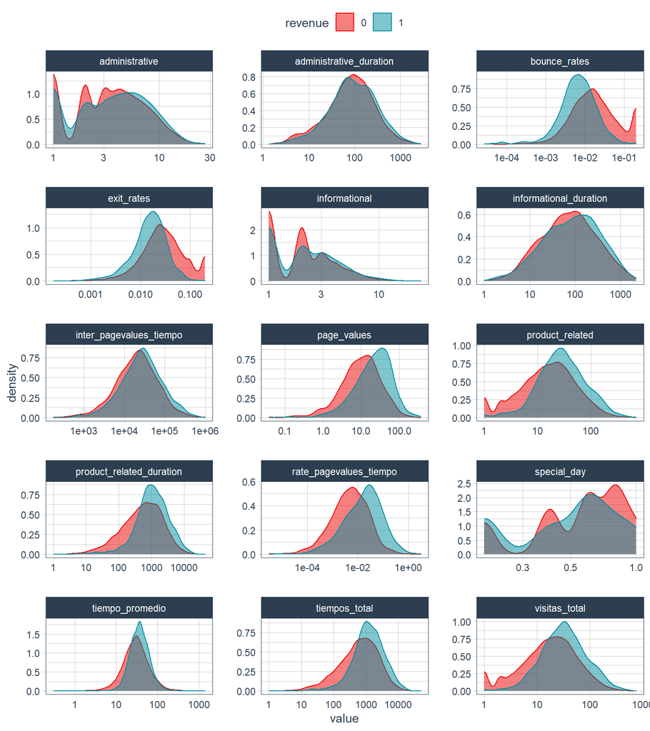

```r
train_final %>%
  select(!is.factor, -id) %>%
  select(!is.character) %>%
  mutate(revenue = as.factor(revenue)) %>%
  pivot_longer(cols = -revenue) %>%
  ggplot(aes(x = value, fill = revenue, color = revenue)) +
  facet_wrap(~name, scales = "free", ncol = 3) +
  geom_density(alpha = 0.5) +
  scale_x_log10() +
  colores +
  relleno +
  theme(legend.position = "top")
```

## Distribución categóricas

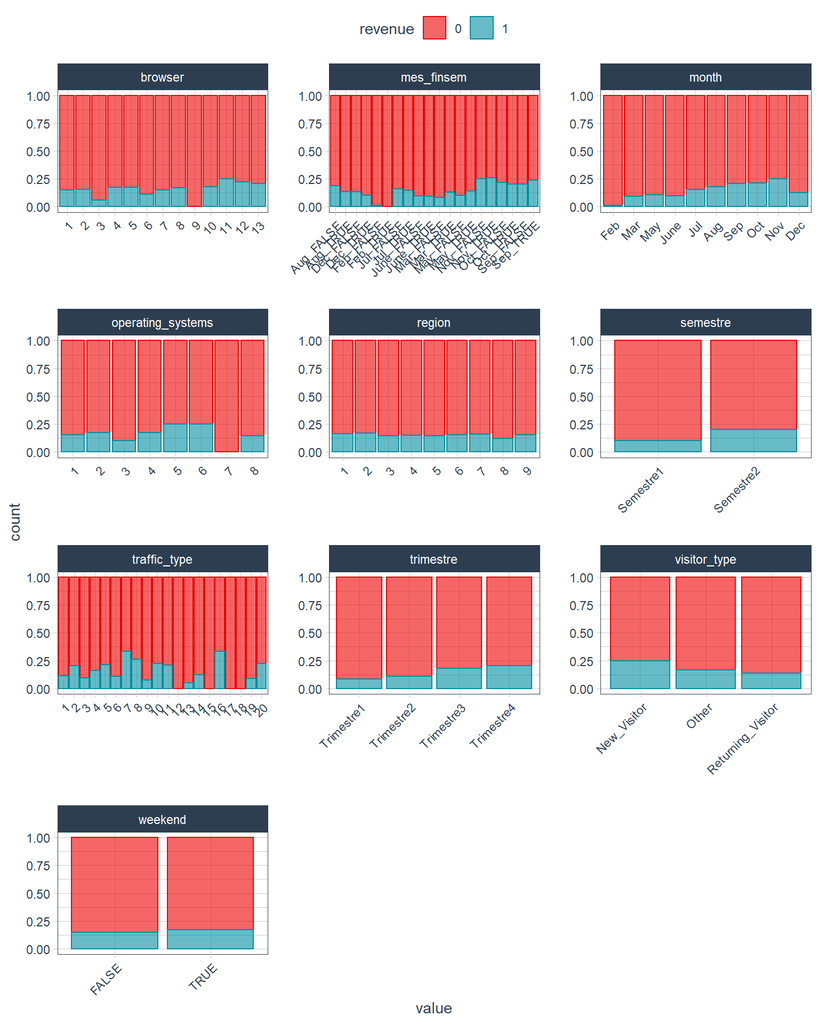

```r
train_final %>%
  mutate(across(is.character, as.factor)) %>%
  select(is.factor, revenue) %>%
  mutate(revenue = as.factor(revenue)) %>%
  pivot_longer(cols = -revenue) %>%
  ggplot(aes(x = value, fill = revenue, color = revenue)) +
  facet_wrap(~name, scales = "free", ncol = 3) +
  geom_bar(position = "fill", alpha = 0.6) +
  colores +
  relleno +
  theme(axis.text.x = element_text(angle = 45, hjust = 1),
        legend.position = "top")
```

# Exportando train y test

```r
save(train_final, file = "data/train_final.Rdata", compress = "xz")
save(test_final, file = "data/test_final.Rdata", compress = "xz")
```